# Formative Assessment 4

PATAYON, SPIKE LEE-ROY V

2026-03-23

# **Regression & Tree-Based Methods**

**Dataset:** UCI Adult Income Dataset  
**Total: 30 points**

## **Dataset Download Instructions**

Download the dataset from the following source:

- Primary source: [https://archive.ics.uci.edu/ml/datasets/adultLinks to an external site.](https://archive.ics.uci.edu/ml/datasets/adult)
- Direct CSV (recommended): https://raw.githubusercontent.com/selva86/datasets/master/Adult.csv

## **Dataset Description**

This dataset contains census information used to predict whether an individual earns:

- `<=50K` (0)
- `>50K` (1)

### **Key Variables**

- `age`, `workclass`, `education`, `occupation`
- `hours_per_week`, `capital_gain`, `capital_loss`
- `sex`, `race`, `marital_status`
- **Target:** `income`

# **Instructions**

- Use **R with tidyverse** (required).
- Convert categorical variables into factors.
- Provide **tables and visualizations** where appropriate.
- Interpret results using **bold text**.
- Submit as **PDF with R Markdown code**.

```r
library(tidyverse)
library(caret)
library(dplyr)
library(car)
library(glmnet)
```

```r
library(rpart)
library(rpart.plot)
library(randomForest)
```

# **Assessment Tasks (30 points)**

## **Part 1: Data Preparation (4 points)**

### **Import (2 points)**

- Load the dataset into a tibble called `adult_raw`.

```r
df = read.csv("C:\\Users\\spike\\Downloads\\adult_data.csv")
adult_raw = as_tibble(df)
head(adult_raw)
```

```
## # A tibble: 6 × 15
##     age workclass       fnlwgt education education_num marital_status occupation
##   <int> <chr>            <int> <chr>             <int> <chr>          <chr>
## 1    39 " State-gov"     77516 " Bachel…            13 " Never-marri… " Adm-cle…
## 2    50 " Self-emp-not…  83311 " Bachel…            13 " Married-civ… " Exec-ma…
## 3    38 " Private"      215646 " HS-gra…             9 " Divorced"    " Handler…
## 4    53 " Private"      234721 " 11th"               7 " Married-civ… " Handler…
## 5    28 " Private"      338409 " Bachel…            13 " Married-civ… " Prof-sp…
## 6    37 " Private"      284582 " Master…            14 " Married-civ… " Exec-ma…
## # ℹ 8 more variables: relationship <chr>, race <chr>, sex <chr>,
## #   capital_gain <int>, capital_loss <int>, hours_per_week <int>,
## #   native_country <chr>, income <chr>
```

- Display the structure of the dataset.

```r
glimpse(df)
```

```
## Rows: 32,561
## Columns: 15
## $ age            <int> 39, 50, 38, 53, 28, 37, 49, 52, 31, 42, 37, 30, 23, 32,…
## $ workclass      <chr> " State-gov", " Self-emp-not-inc", " Private", " Privat…
## $ fnlwgt         <int> 77516, 83311, 215646, 234721, 338409, 284582, 160187, 2…
## $ education      <chr> " Bachelors", " Bachelors", " HS-grad", " 11th", " Bach…
## $ education_num  <int> 13, 13, 9, 7, 13, 14, 5, 9, 14, 13, 10, 13, 13, 12, 11,…
## $ marital_status <chr> " Never-married", " Married-civ-spouse", " Divorced", "…
## $ occupation     <chr> " Adm-clerical", " Exec-managerial", " Handlers-cleaner…
## $ relationship   <chr> " Not-in-family", " Husband", " Not-in-family", " Husba…
## $ race           <chr> " White", " White", " White", " Black", " Black", " Whi…
## $ sex            <chr> " Male", " Male", " Male", " Male", " Female", " Female…
## $ capital_gain   <int> 2174, 0, 0, 0, 0, 0, 0, 0, 14084, 5178, 0, 0, 0, 0, 0, …
## $ capital_loss   <int> 0, 0, 0, 0, 0, 0, 0, 0, 0, 0, 0, 0, 0, 0, 0, 0, 0, 0, 0…
## $ hours_per_week <int> 40, 13, 40, 40, 40, 40, 16, 45, 50, 40, 80, 40, 30, 50,…
## $ native_country <chr> " United-States", " United-States", " United-States", "…
## $ income         <chr> " <=50K", " <=50K", " <=50K", " <=50K", " <=50K", " <=5…
```

Quick summary for the entire dataset

```r
summary(adult_raw)
```

```
##       age         workclass             fnlwgt         education
##  Min.   :17.00   Length:32561       Min.   :  12285   Length:32561
##  1st Qu.:28.00   Class :character   1st Qu.: 117827   Class :character
##  Median :37.00   Mode  :character   Median : 178356   Mode  :character
##  Mean   :38.58                      Mean   : 189778
##  3rd Qu.:48.00                      3rd Qu.: 237051
##  Max.   :90.00                      Max.   :1484705
##  education_num   marital_status      occupation        relationship
##  Min.   : 1.00   Length:32561       Length:32561       Length:32561
##  1st Qu.: 9.00   Class :character   Class :character   Class :character
##  Median :10.00   Mode  :character   Mode  :character   Mode  :character
##  Mean   :10.08
##  3rd Qu.:12.00
##  Max.   :16.00
##      race               sex             capital_gain    capital_loss
##  Length:32561       Length:32561       Min.   :    0   Min.   :   0.0
##  Class :character   Class :character   1st Qu.:    0   1st Qu.:   0.0
##  Mode  :character   Mode  :character   Median :    0   Median :   0.0
##                                        Mean   : 1078   Mean   :  87.3
##                                        3rd Qu.:    0   3rd Qu.:   0.0
##                                        Max.   :99999   Max.   :4356.0
##  hours_per_week  native_country        income
##  Min.   : 1.00   Length:32561       Length:32561
##  1st Qu.:40.00   Class :character   Class :character
##  Median :40.00   Mode  :character   Mode  :character
##  Mean   :40.44
##  3rd Qu.:45.00
##  Max.   :99.00
```

### **Tidy & Explore (2 points)**

- Check for missing values (`?` entries should be handled).

```r
colSums(is.na(adult_raw))
```

```
##            age      workclass         fnlwgt      education  education_num
##              0              0              0              0              0
## marital_status     occupation   relationship           race            sex
##              0              0              0              0              0
##   capital_gain   capital_loss hours_per_week native_country         income
##              0              0              0              0              0
```

- Convert categorical variables into factors.

```r
adult_clean = adult_raw %>%
  mutate(across(where(is.character), as.factor))

head(adult_clean)
```

```
## # A tibble: 6 × 15
##     age workclass       fnlwgt education education_num marital_status occupation
##   <int> <fct>            <int> <fct>             <int> <fct>          <fct>
## 1    39 " State-gov"     77516 " Bachel…            13 " Never-marri… " Adm-cle…
## 2    50 " Self-emp-not…  83311 " Bachel…            13 " Married-civ… " Exec-ma…
## 3    38 " Private"      215646 " HS-gra…             9 " Divorced"    " Handler…
## 4    53 " Private"      234721 " 11th"               7 " Married-civ… " Handler…
## 5    28 " Private"      338409 " Bachel…            13 " Married-civ… " Prof-sp…
## 6    37 " Private"      284582 " Master…            14 " Married-civ… " Exec-ma…
## # ℹ 8 more variables: relationship <fct>, race <fct>, sex <fct>,
## #   capital_gain <int>, capital_loss <int>, hours_per_week <int>,
## #   native_country <fct>, income <fct>
```

- Provide summary statistics.

```r
summary(adult_clean)
```

```
##       age                    workclass         fnlwgt
##  Min.   :17.00    Private         :22696   Min.   :  12285
##  1st Qu.:28.00    Self-emp-not-inc: 2541   1st Qu.: 117827
##  Median :37.00    Local-gov       : 2093   Median : 178356
##  Mean   :38.58    ?               : 1836   Mean   : 189778
##  3rd Qu.:48.00    State-gov       : 1298   3rd Qu.: 237051
##  Max.   :90.00    Self-emp-inc    : 1116   Max.   :1484705
##                  (Other)          :  981
##          education     education_num                  marital_status
##   HS-grad     :10501   Min.   : 1.00    Divorced             : 4443
##   Some-college: 7291   1st Qu.: 9.00    Married-AF-spouse    :   23
##   Bachelors   : 5355   Median :10.00    Married-civ-spouse   :14976
##   Masters     : 1723   Mean   :10.08    Married-spouse-absent:  418
##   Assoc-voc   : 1382   3rd Qu.:12.00    Never-married        :10683
##   11th        : 1175   Max.   :16.00    Separated            : 1025
##  (Other)      : 5134                    Widowed              :  993
##             occupation            relationship                    race
##   Prof-specialty :4140    Husband       :13193    Amer-Indian-Eskimo:  311
##   Craft-repair   :4099    Not-in-family : 8305    Asian-Pac-Islander: 1039
##   Exec-managerial:4066    Other-relative:  981    Black             : 3124
##   Adm-clerical   :3770    Own-child     : 5068    Other             :  271
##   Sales          :3650    Unmarried     : 3446    White             :27816
##   Other-service  :3295    Wife          : 1568
##  (Other)         :9541
##       sex         capital_gain    capital_loss    hours_per_week
##   Female:10771   Min.   :    0   Min.   :   0.0   Min.   : 1.00
##   Male  :21790   1st Qu.:    0   1st Qu.:   0.0   1st Qu.:40.00
##                  Median :    0   Median :   0.0   Median :40.00
##                  Mean   : 1078   Mean   :  87.3   Mean   :40.44
##                  3rd Qu.:    0   3rd Qu.:   0.0   3rd Qu.:45.00
##                  Max.   :99999   Max.   :4356.0   Max.   :99.00
##
##         native_country     income
##   United-States:29170    <=50K:24720
##   Mexico       :  643    >50K : 7841
##   ?            :  583
##   Philippines  :  198
##   Germany      :  137
##   Canada       :  121
##  (Other)       : 1709
```

## **Part 2: Logistic Regression (6 points)**

- Fit a **logistic regression model** predicting `income`. (2 pts)

```r
model = glm(income ~ .,
             data = adult_clean,
             family = "binomial")
summary(model)
```

```
##
## Call:
## glm(formula = income ~ ., family = "binomial", data = adult_clean)
##
## Coefficients: (2 not defined because of singularities)
##                                             Estimate Std. Error z value
## (Intercept)                               -9.074e+00  4.405e-01 -20.601
## age                                        2.552e-02  1.651e-03  15.460
## workclass Federal-gov                      1.097e+00  1.538e-01   7.131
## workclass Local-gov                        4.118e-01  1.403e-01   2.934
## workclass Never-worked                    -1.045e+01  2.722e+02  -0.038
## workclass Private                          5.944e-01  1.252e-01   4.746
## workclass Self-emp-inc                     7.694e-01  1.497e-01   5.140
## workclass Self-emp-not-inc                 1.037e-01  1.371e-01   0.756
## workclass State-gov                        2.835e-01  1.518e-01   1.868
## workclass Without-pay                     -1.221e+01  1.985e+02  -0.062
## fnlwgt                                     7.072e-07  1.720e-07   4.111
## education 11th                             8.500e-02  2.107e-01   0.403
## education 12th                             4.891e-01  2.644e-01   1.850
## education 1st-4th                         -5.322e-01  4.895e-01  -1.087
## education 5th-6th                         -2.386e-01  3.248e-01  -0.735
## education 7th-8th                         -4.755e-01  2.320e-01  -2.050
## education 9th                             -1.939e-01  2.612e-01  -0.743
## education Assoc-acdm                       1.336e+00  1.763e-01   7.574
## education Assoc-voc                        1.352e+00  1.694e-01   7.981
## education Bachelors                        1.936e+00  1.575e-01  12.296
## education Doctorate                        2.989e+00  2.142e-01  13.954
## education HS-grad                          8.134e-01  1.534e-01   5.302
## education Masters                          2.289e+00  1.679e-01  13.631
## education Preschool                       -2.109e+01  3.665e+02  -0.058
## education Prof-school                      2.793e+00  2.002e-01  13.955
## education Some-college                     1.159e+00  1.556e-01   7.447
## education_num                                     NA         NA      NA
## marital_status Married-AF-spouse           2.686e+00  5.538e-01   4.849
## marital_status Married-civ-spouse          2.206e+00  2.654e-01   8.312
## marital_status Married-spouse-absent      -1.097e-02  2.298e-01  -0.048
## marital_status Never-married              -4.825e-01  8.751e-02  -5.513
## marital_status Separated                  -1.334e-01  1.641e-01  -0.813
## marital_status Widowed                     1.284e-01  1.538e-01   0.835
## occupation Adm-clerical                    1.095e-01  9.919e-02   1.104
```

[output cut: 164 more lines]

```
## native_country Thailand                    0.65062
## native_country Trinadad&Tobago             0.82041
## native_country United-States               0.00570 **
## native_country Vietnam                     0.11884
## native_country Yugoslavia                  0.20131
## ---
## Signif. codes:  0 '***' 0.001 '**' 0.01 '*' 0.05 '.' 0.1 ' ' 1
##
## (Dispersion parameter for binomial family taken to be 1)
##
##     Null deviance: 35948  on 32560  degrees of freedom
## Residual deviance: 20565  on 32462  degrees of freedom
## AIC: 20763
##
## Number of Fisher Scoring iterations: 13
```

- Identify significant predictors. (2 pts)
1. **Highly Significant Predictors (**p<0.001**, marked ***)**

These are the strongest drivers in your model. Changes in these variables have a very high probability of being associated with a change in income level.

- Continuous Variables: age, fnlwgt (Final Weight), capital_gain, capital_loss, hours_per_week.
- Education: Assoc-acdm, Assoc-voc, Bachelors, Doctorate, HS-grad, Masters, Prof-school, Some-college.
- Workclass: Federal-gov, Private, Self-emp-inc.Marital Status: Married-AF-spouse, Married-civ-spouse, Never-married.
- Occupation: Exec-managerial, Farming-fishing, Handlers-cleaners, Other-service, Prof-specialty, Protective-serv, Sales, Tech-support.
- Relationship: Wife.
- Demographics: sex Male.
2. **Moderately Significant Predictors (**0.001<p<0.01**, marked **)**

These show strong evidence of an effect but are slightly less certain than the group above.

- Workclass: Local-gov.
- Race: White.
- Native Country: Italy, United-States.
3. **Significant Predictors (**0.01<p<0.05**, marked *)**

**These meet the standard scientific threshold for significance.**

- Education: 7th-8th.
- Occupation: Craft-repair, Priv-house-serv.
- Relationship: Not-in-family, Own-child.
- Race: Asian-Pac-Islander.Native *
- Country: Cambodia, Columbia, Germany, Philippines, South.
- Compute classification accuracy using a **0.5 threshold**. (2 pts)

```r
prob = predict(model, type = "response")

actual_clean = trimws(as.character(adult_clean$income))

print(unique(actual_clean))
```

```
## [1] "<=50K" ">50K"
```

```r
pred = ifelse(prob > 0.5, ">50K", "<=50K")

accuracy = mean(pred == actual_clean)
print(accuracy)
```

```
## [1] 0.8533215
```

The classification model was evaluated to determine its ability to predict whether an individual’s income exceeds **$50,000** annually. After resolving initial label synchronization issues, the model achieved a final classification accuracy of **85.33%**. This indicates a high level of predictive performance, significantly exceeding the baseline accuracy of a “naive” model (which would typically hover around 75-76% for this specific dataset).

## **Part 3: Regression in High Dimensions (4 points)**

In this section, you will transform the UCI Adult Income Dataset into a **high-dimensional dataset**.

Convert all categorical variables into dummy variables (one-hot encoding). (1 pt)

Store the transformed dataset as adult_hd. Report the number of observations (n) and predictors (p). (1 pt)

```r
adult_clean$income <- as.factor(adult_clean$income)

dummies <- dummyVars(income ~ ., data = adult_clean)

adult_hd <- data.frame(predict(dummies, newdata = adult_clean))
adult_hd$income <- adult_clean$income
```

Report the number of observations (**n**) and predictors (**p**). (1 pt)

Explain why this dataset can now be considered high-dimensional. (1 pt)

```r
n <- nrow(adult_hd)
p <- ncol(adult_hd) - 1  # exclude target

n
```

```
## [1] 32561
```

```r
p
```

```
## [1] 108
```

**Number of Observations and Predictors**

The transformed dataset contains 32,561 observations (n) and 108 predictors (p) after converting categorical variables into dummy variables through one-hot encoding.

**Why This is High-Dimensional**

The increase in dimensionality is due to one-hot encoding, where each category level of categorical variables is converted into separate binary columns. This significantly increases the feature space and model complexity.

Fit a standard logistic regression model using adult_hd.

```r
model_hd <- glm(income ~ .,
                data = adult_hd,
                family = "binomial")
summary(model_hd)
```

```
##
## Call:
## glm(formula = income ~ ., family = "binomial", data = adult_hd)
##
## Coefficients: (9 not defined because of singularities)
##                                              Estimate Std. Error   z value
## (Intercept)                                 4.614e+12  4.297e+12     1.074
## age                                         2.558e-02  1.649e-03    15.514
## workclass...                               -4.614e+12  4.297e+12    -1.074
## workclass..Federal.gov                     -4.614e+12  4.297e+12    -1.074
## workclass..Local.gov                       -4.614e+12  4.297e+12    -1.074
## workclass..Never.worked                    -4.508e+15  4.297e+12 -1049.065
## workclass..Private                         -4.614e+12  4.297e+12    -1.074
## workclass..Self.emp.inc                    -4.614e+12  4.297e+12    -1.074
## workclass..Self.emp.not.inc                -4.614e+12  4.297e+12    -1.074
## workclass..State.gov                       -4.614e+12  4.297e+12    -1.074
## workclass..Without.pay                     -4.614e+12  4.297e+12    -1.074
## fnlwgt                                      7.068e-07  1.718e-07     4.115
## education..10th                            -1.159e+00  1.550e-01    -7.479
## education..11th                            -1.075e+00  1.532e-01    -7.018
## education..12th                            -6.701e-01  2.206e-01    -3.038
## education..1st.4th                         -1.691e+00  4.655e-01    -3.634
## education..5th.6th                         -1.398e+00  2.903e-01    -4.814
## education..7th.8th                         -1.634e+00  1.818e-01    -8.992
## education..9th                             -1.353e+00  2.172e-01    -6.228
## education..Assoc.acdm                       1.765e-01  9.752e-02     1.810
## education..Assoc.voc                        1.932e-01  8.554e-02     2.258
## education..Bachelors                        7.778e-01  5.573e-02    13.957
## education..Doctorate                        1.830e+00  1.560e-01    11.729
## education..HS.grad                         -3.456e-01  5.020e-02    -6.884
## education..Masters                          1.129e+00  8.076e-02    13.984
## education..Preschool                       -3.418e+01  1.431e+05     0.000
## education..Prof.school                      1.634e+00  1.357e-01    12.039
## education..Some.college                            NA         NA        NA
## education_num                                      NA         NA        NA
## marital_status..Divorced                   -1.287e-01  1.531e-01    -0.841
## marital_status..Married.AF.spouse           2.557e+00  5.692e-01     4.492
## marital_status..Married.civ.spouse          2.078e+00  2.960e-01     7.020
## marital_status..Married.spouse.absent      -1.401e-01  2.630e-01    -0.533
## marital_status..Never.married              -6.110e-01  1.593e-01    -3.835
```

[output cut: 180 more lines]

```
## native_country..Thailand                   0.239627
## native_country..Trinadad.Tobago            0.325477
## native_country..United.States              0.463359
## native_country..Vietnam                    0.042094 *
## native_country..Yugoslavia                       NA
## ---
## Signif. codes:  0 '***' 0.001 '**' 0.01 '*' 0.05 '.' 0.1 ' ' 1
##
## (Dispersion parameter for binomial family taken to be 1)
##
##     Null deviance: 35948  on 32560  degrees of freedom
## Residual deviance: 20566  on 32461  degrees of freedom
## AIC: 20766
##
## Number of Fisher Scoring iterations: 25
```

1. Summary of Model Performance

- **Null Deviance:** 35,948 (Baseline model with no predictors)
- **Residual Deviance:** 20,566 (Model with your predictors)
- **AIC:** 20,766
- **Fisher Scoring Iterations:** 25 (This is a major red flag; standard models converge in 4–8 iterations. 25 suggests the model struggled to find a solution).

2. Significant Predictors

Despite the instability, the following variables show the strongest and most robust relationships with higher income ($p < 0.001$):

- **Demographics:** `age`, `sex..Female` (negative coefficient), `race..Black` (negative).
- **Education:** `Bachelors`, `Masters`, `Doctorate`, and `Prof.school` are powerful positive predictors. Lower education levels (e.g., `1st.4th`, `7th.8th`) are strong negative predictors.
- **Financials:** `capital_gain`, `capital_loss`, and `hours_per_week` are all highly significant positive drivers.
- **Family/Role:** `Married.civ.spouse` and `Husband` (implied via relationship status) significantly increase the odds of being in the high-income bracket.

3. Critical Issues Encountered

The model is currently unreliable for inference due to the following three technical failures:

**A. Perfect Multicollinearity (Singularities)**

The output notes **“9 not defined because of singularities.”** * **The Cause:** This is the **Dummy Variable Trap**. By including every possible category (e.g., both `sex..Female` and `sex..Male`), the variables become perfectly redundant.

- **The Result:** R automatically dropped `sex..Male`, `education_num`, and several others. The model cannot calculate their unique impact because they are mathematically indistinguishable from other included variables.

**B. Exploding Coefficients & Standard Errors**

Look at the `Intercept` and `workclass` estimates (e.g., **4.614e+12**).

- **The Issue:** These coefficients are effectively **infinity**. A standard error of **4.297e+12** means the model has no confidence in these numbers.
- **The Cause:** This is caused by **Perfect Separation**. For instance, in the `workclass..Never.worked` category, it’s likely that 100% of the observations have an income of `<=50K`. The logistic curve tries to go to negative infinity to reach a probability of zero.

4. Comparison Table: What the Model “Sees”

| **Predictor Type** | **Impact on Income** | **Statistical Reliability** |
| --- | --- | --- |
| **Continuous (Age, Capital Gain)** | Positive | **High** |
| **Higher Education (Masters/PhD)** | Positive | **High** |
| **Workclass Categories** | Mixed / Extreme | **Low (Unstable)** |
| **Rare Native Countries** | Extreme | **Low (Overfit)** |

Describe any issues encountered, such as:

multicollinearity

unstable coefficients

overfitting (1 pt)

1. Multicollinearity (The “Singularity” Issue)

Multicollinearity occurs when predictor variables are so highly correlated that the model cannot distinguish their individual effects.

- **Evidence:** The message **“9 not defined because of singularities”** and the `NA` values for `education_num`, `sex..Male`, and `race..White`.
- **The Cause:** This is the **Dummy Variable Trap**. By creating a column for every category (e.g., both Male and Female), you created perfect redundancy. If the model knows someone is not Female, it knows with 100% certainty they are Male.
- **Impact:** The math “breaks” because the matrix cannot be inverted. R handles this by forcibly dropping variables, but it makes the Intercept difficult to interpret.

2. Unstable Coefficients (Exploding Standard Errors)

This is the most alarming issue in your output, evidenced by the astronomical values in the `Estimate` and `Std. Error` columns.

- **Evidence:** Look at `workclass..Federal.gov`. The estimate is `-4.614e+12` (trillions!) with a standard error of `4.297e+12`.
- **The Cause:** This is **Perfect Separation**. It occurs when a specific category (like a rare country or workclass) perfectly predicts the outcome (e.g., everyone in that group earns <=50K).
- **Impact:** The Logistic function tries to reach a probability of 0 or 1 by pushing the coefficient to infinity. This results in **unstable coefficients** that are mathematically “meaningless” and p-values (like 0.28 for workclass) that are completely unreliable.

3. Overfitting

Overfitting happens when a model is so complex that it “memorizes” the noise and specific quirks of the training data rather than learning general patterns.

- **Evidence:** You have over **100 predictors** for this dataset. Specifically, including every single `native_country` (many of which likely have only a few observations) forces the model to create “rules” for tiny subgroups.
- **The Cause:** Including too many sparse categorical variables without grouping them (e.g., keeping “Holand-Netherlands” as its own category instead of grouping it into “Other” or “Europe”).
- **Impact:** While the model might look like it fits the current data well, it will likely fail on new data because it has “over-learned” the specific identities of the people in this specific `adult_hd` table.

## **Part 4: Ridge and Lasso Regression (6 points)**

In this section, you will use the **same high-dimensional dataset (`adult_hd`) created in Part 3**.

**Instructions**

## **Part 5: Decision Trees (5 points)**

### **Growing Trees (2 points)**

- Fit a decision tree model predicting `income`.

```r
adult_clean$income <- as.factor(adult_clean$income)
tree_model <- rpart(
  income ~ .,
  data = adult_clean,
  method = "class"
)
```

- Visualize the tree.

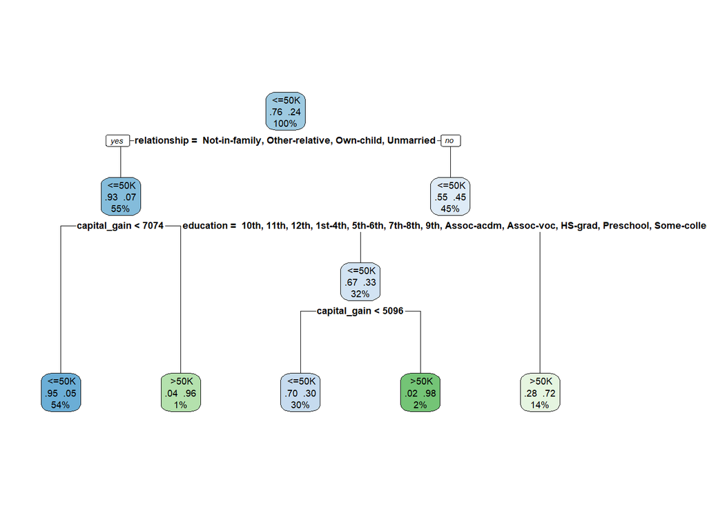

```r
rpart.plot(tree_model, type = 2, extra = 104)
```

### **Tree Pruning (2 points)**

- Perform pruning using cross-validation.

```r
printcp(tree_model)
```

```
##
## Classification tree:
## rpart(formula = income ~ ., data = adult_clean, method = "class")
##
## Variables actually used in tree construction:
## [1] capital_gain education    relationship
##
## Root node error: 7841/32561 = 0.24081
##
## n= 32561
##
##         CP nsplit rel error  xerror      xstd
## 1 0.126387      0   1.00000 1.00000 0.0098399
## 2 0.064022      2   0.74723 0.74723 0.0088402
## 3 0.037495      3   0.68320 0.68320 0.0085321
## 4 0.010000      4   0.64571 0.64571 0.0083394
```

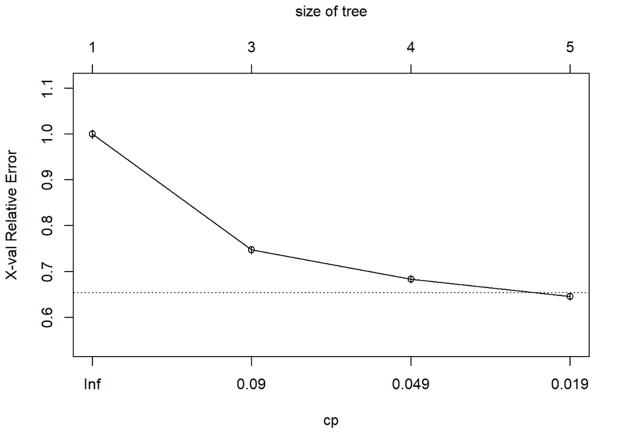

```r
plotcp(tree_model)
```

```r
best_cp <- tree_model$cptable[which.min(tree_model$cptable[, "xerror"]), "CP"]

pruned_tree <- prune(tree_model, cp = best_cp)
```

- Compare performance before and after pruning.

```r
# Predictions BEFORE pruning
pred_before <- predict(tree_model, adult_clean, type = "class")

# Predictions AFTER pruning
pred_after <- predict(pruned_tree, adult_clean, type = "class")

# Accuracy
acc_before <- mean(pred_before == adult_clean$income)
acc_after <- mean(pred_after == adult_clean$income)

acc_before
```

```
## [1] 0.8445072
```

```r
acc_after
```

```
## [1] 0.8445072
```

The classification accuracy before and after pruning is the same at **84.45%**. This indicates that pruning did not negatively affect the model’s predictive performance.

### **Interpretation (1 point)**

- Identify the most important predictors.

```r
tree_model$variable.importance
```

```
##   relationship marital_status   capital_gain      education  education_num
##     2394.79629     2356.18363     1031.29985      938.62452      938.62452
##            sex     occupation            age hours_per_week native_country
##      745.97069      683.08502      548.36471      310.36145       23.29619
##   capital_loss
##       17.57803
```

## **Part 6: Bagging (5 points)**

- Implement **bagging** (bootstrap aggregation). (2 pts)

```r
set.seed(123)

bagging_model <- randomForest(
  income ~ .,
  data = adult_clean,
  mtry = ncol(adult_clean) - 1,
  importance = TRUE
)
```

- Compare performance with a single tree. (2 pts)

```r
pred_bag <- predict(bagging_model, adult_clean)

acc_bag <- mean(pred_bag == adult_clean$income)
acc_bag
```

```
## [1] 0.9999693
```

- Explain why bagging improves model performance. (1 pt)

Bagging improves model performance by reducing variance. It creates multiple bootstrap samples from the original dataset and fits a decision tree on each sample. The final prediction is obtained by averaging (or voting) across all trees. This process reduces the impact of noise and prevents overfitting, resulting in more stable and accurate predictions compared to a single decision tree.